# Praca domowa 1 xai

Paweł Fijałkowski

24/03/2021

## Temat pracy

Praca powstała jako realizacja prostej analizy wyjaśniającej decyzję modelu uczenia maszynowego - lasu losowego.  
Problem klasyfikacyjny z jakim będziemy pracować to problem określenia zdolności kredytowej klientów niemieckiego banku (`good` i `bad`).

```r
german_credit <- read.csv("german-credit.csv")
model <- ranger::ranger(class~., data = german_credit, classification = TRUE, probability = TRUE)
explainer <- explain(model = model,data = german_credit,y = german_credit$customer_type)
```

```
## Preparation of a new explainer is initiated
##   -> model label       :  ranger  (  default  )
##   -> data              :  1000  rows  21  cols
##   -> target variable   :  not specified! (  WARNING  )
##   -> predict function  :  yhat.ranger  will be used (  default  )
##   -> predicted values  :  No value for predict function target column. (  default  )
##   -> model_info        :  package ranger , ver. 0.12.1 , task classification (  default  )
##   -> model_info        :  Model info detected classification task but 'y' is a NULL .  (  WARNING  )
##   -> model_info        :  By deafult classification tasks supports only numercical 'y' parameter.
##   -> model_info        :  Consider changing to numerical vector with 0 and 1 values.
##   -> model_info        :  Otherwise I will not be able to calculate residuals or loss function.
##   -> predicted values  :  numerical, min =  0.1232778 , mean =  0.6965237 , max =  0.9860476
##   -> residual function :  difference between y and yhat (  default  )
##   A new explainer has been created!
```

Po imporcie danych, stworzeniu obiektu modelu i explainera, dokonajmy odpowiednich predykcji.  
Wybierzmy do tego celu obserwacje `123`.

```r
prediction_123 <- predict(model, german_credit[123,])
true_val_123 <- german_credit[123,"class"]
true_val_123
```

```
## [1] good
## Levels: bad good
```

```r
good_prob <- prediction_123$predictions[2]
```

Widzimy, że poprawna wartość to `good`, a nasz podel przewidział to z prawdopodobieństwem: 0.8810024.  
Takie wyniki wydają się dość satysfakcjonujące z punktu widzenia dokładności predykcji.

## Wyjaśnienie predykcji

Użyjemy `predict_parts` do wytłumaczenia podjętych przez model decyzji.  
(Dlaczego klientowi `123` przyporządkowany klasę `good` z takim wysokim prawdopodobieństwem?)

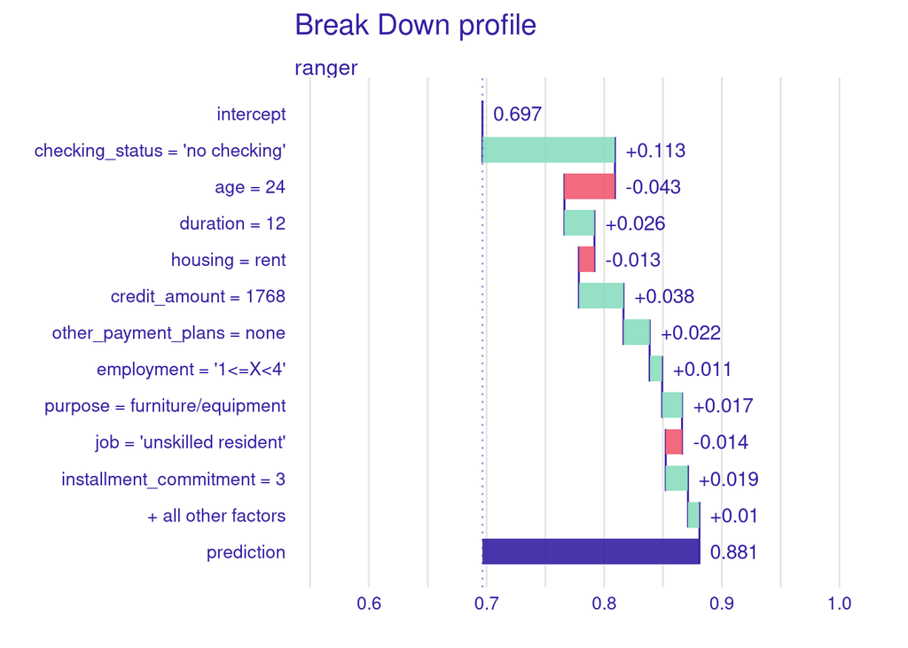

```r
p <- predict_parts(explainer = explainer, new_observation = german_credit[123,])
plot(p)
```

Teraz do tego samego celu wykorzystajmy metodę dekompozycji Shapa.

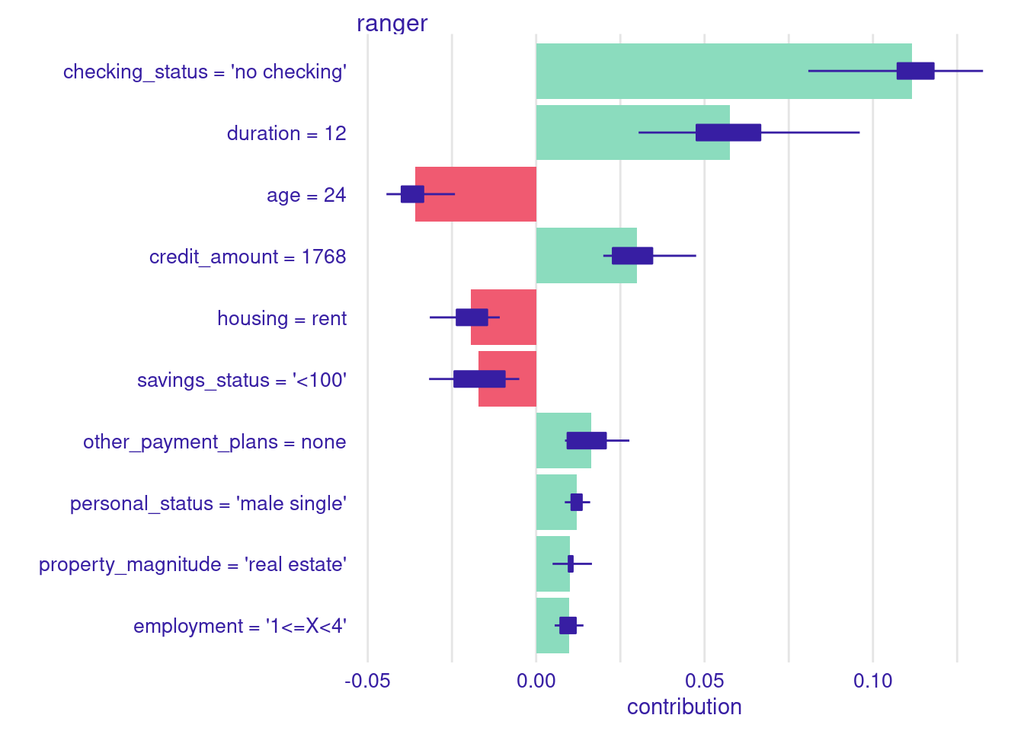

```r
p2 <- predict_parts(explainer, new_observation = german_credit[123,], type = "shap", B = 10)
plot(p2)
```

Zauważmy, że największy wpływ na predykcję dla obserwacji `123` miały zmienne `checking_status` i `duration`.  
Poszukajmy więc obserwacji dla której hierarchia wpływu zmiennych się różni.

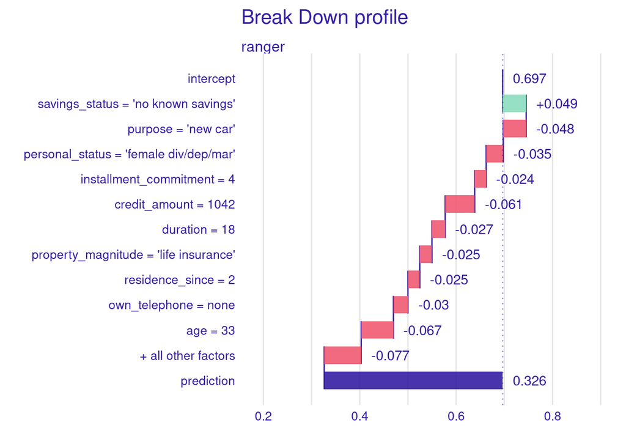

```r
p3 <- predict_parts(explainer, new_observation = german_credit[420,])
plot(p3)
```

Poszukajmy teraz obserwacji na której predykcję negatywnie wpływać będzie wartość zmiennej `checking_status`.

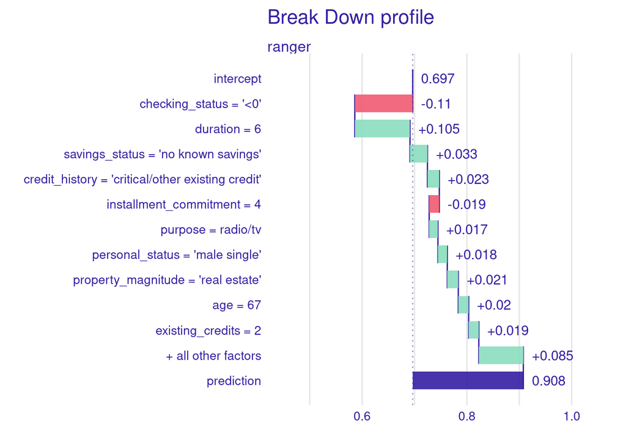

```r
p4 <- predict_parts(explainer, new_observation = german_credit[1,])
plot(p4)
```

## Wnioski

Metody `break down` pozwoliły nam stwierdzić, że największy wpływ na predykcję modelu mają zmienne `checking_status`, `duration` i `age`. Wydaje się to zgodne z naszymi intuicyjami. Młody wiek kredytobiorcy i niskie saldo konta oszczędnościowego zwiększa prawdopodobieństwo klasyfikacji do klasy `bad`. Analizując jednak jedynie pojedyncze obserwację nie jesteśmy w stanie jednoznacznie skonkludować co do wpływu poszczególnych zmiennych w ogólności w przypadku wszystkich obserwacji.